# IODS course project

The aim is to keep only the PCs that explain the most variance of our data to make the interpretation easier.

**PCA on Unstandardise data**

```r
# perform principal component analysis (with the SVD method)
pca_human1 <- prcomp(human)
summary(pca_human1)
```

```
## Importance of components:
##                              PC1      PC2   PC3   PC4   PC5   PC6    PC7
## Standard deviation     1.854e+04 185.5219 25.19 11.45 3.766 1.566 0.1912
## Proportion of Variance 9.999e-01   0.0001  0.00  0.00 0.000 0.000 0.0000
## Cumulative Proportion  9.999e-01   1.0000  1.00  1.00 1.000 1.000 1.0000
##                           PC8
## Standard deviation     0.1591
## Proportion of Variance 0.0000
## Cumulative Proportion  1.0000
```

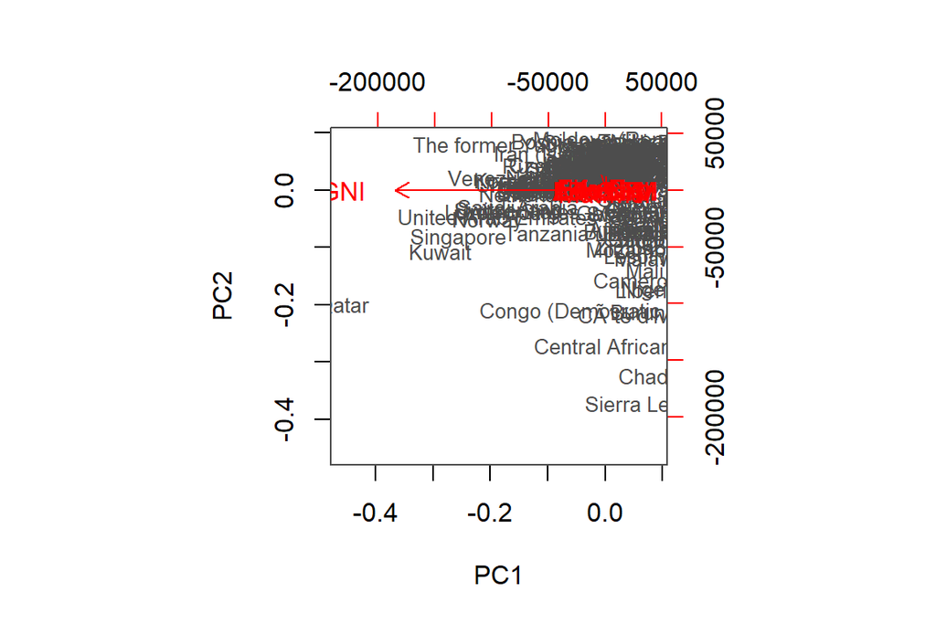

```r
# draw a biplot of the principal component representation and the original variables
biplot(pca_human1, choices = 1:2, cex = c(0.8, 1),col = c("grey30", "red"))
```

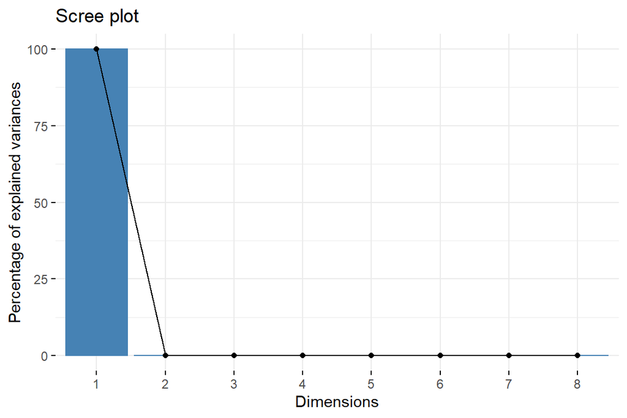

```r
# Access the factoextra
library(factoextra)

#Visualize eigenvalues
fviz_eig(pca_human1)
```

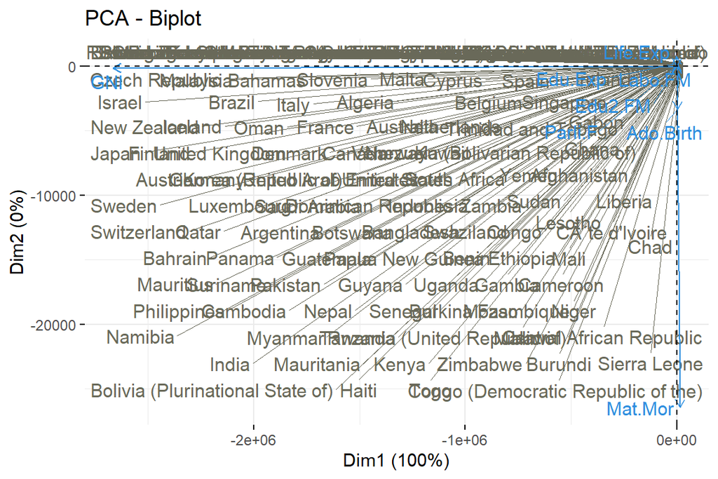

```r
# Another way to draw a biplot of the principal component
# Gives percentage variance of PC1 on the x axis and PC2 on the y axis
fviz_pca_biplot(pca_human1, repel = TRUE, col.var = "#2E8FDF", # Variables color
                col.ind = "#696959"  # Individuals color
                )
```

```r
eig.val <- get_eigenvalue(pca_human1)
eig.val
```

```
##         eigenvalue variance.percent cumulative.variance.percent
## Dim.1 3.438860e+08     9.998976e+01                    99.98976
## Dim.2 3.441836e+04     1.000763e-02                    99.99977
## Dim.3 6.343853e+02     1.844566e-04                    99.99996
## Dim.4 1.312035e+02     3.814929e-05                   100.00000
## Dim.5 1.418457e+01     4.124367e-06                   100.00000
## Dim.6 2.452081e+00     7.129774e-07                   100.00000
## Dim.7 3.655943e-02     1.063017e-08                   100.00000
## Dim.8 2.531638e-02     7.361099e-09                   100.00000
```

Standardization is a advisable for data transformation especially because the variables in original dataset have different scale or different units.

The standardized variables will therefore be unitless and have a similar variance.

This is necessary to eliminate biases in the original variables.

**PCA on Standardise data**

```r
# standardize the variables
human_std <- scale(human)

# perform principal component analysis (with the SVD method)
pca_human2 <- prcomp(human_std)

#The summary shows outputs the proportion of variance explained by the components.
summary(pca_human2)
```

```
## Importance of components:
##                           PC1    PC2     PC3     PC4     PC5     PC6
## Standard deviation     2.0708 1.1397 0.87505 0.77886 0.66196 0.53631
## Proportion of Variance 0.5361 0.1624 0.09571 0.07583 0.05477 0.03595
## Cumulative Proportion  0.5361 0.6984 0.79413 0.86996 0.92473 0.96069
##                            PC7     PC8
## Standard deviation     0.45900 0.32224
## Proportion of Variance 0.02634 0.01298
## Cumulative Proportion  0.98702 1.00000
```

```r
# Access the factoextra
library(factoextra)

#Get eigenvalues to determine the number of principal components to be considered.
eig.val <- get_eigenvalue(pca_human2)
eig.val
```

```
##       eigenvalue variance.percent cumulative.variance.percent
## Dim.1  4.2883701        53.604626                    53.60463
## Dim.2  1.2989625        16.237031                    69.84166
## Dim.3  0.7657100         9.571374                    79.41303
## Dim.4  0.6066276         7.582845                    86.99588
## Dim.5  0.4381862         5.477328                    92.47320
## Dim.6  0.2876242         3.595302                    96.06851
## Dim.7  0.2106805         2.633506                    98.70201
## Dim.8  0.1038390         1.297988                   100.00000
```

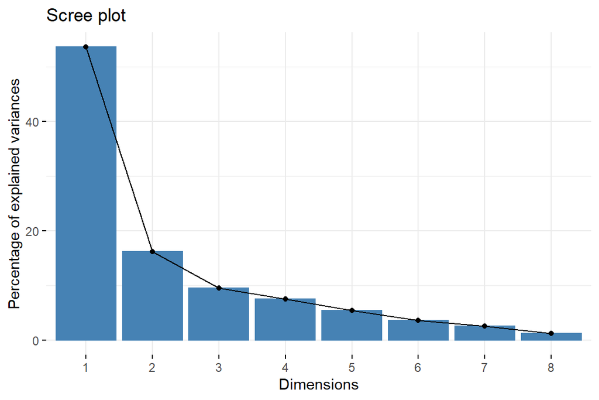

```r
#Visualize eigenvalues
#Scree plot,

fviz_eig(pca_human2)
```

The PCA results for standardised data are are different from unstandardized data.

PCA on standardised data are easier to interprete and see the cooreltion as compared to unstandardised data.

Based on these results

The PC1 account for 53.6% of the total variance and the PC2 16.2%. Thus PC1 and PC2 contributes about 69% of the total variation in the dataset and have eigenvalues > 1 This mean, PC1 and PC2 provides a good approximation of the variation present in the original human dataset that has 8 variable.

```r
# create and print out a summary of pca_human
s <- summary(pca_human2)

# rounded percentages of variance captured by each PC
pca_pr <- round(100*s$importance[2,], digits = 1)

# print out the percentages of variance
pca_pr
```

```
##  PC1  PC2  PC3  PC4  PC5  PC6  PC7  PC8
## 53.6 16.2  9.6  7.6  5.5  3.6  2.6  1.3
```

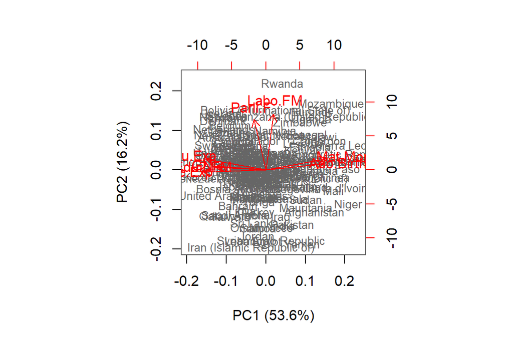

```r
# create object pc_lab to be used as axis labels
pc_lab <- paste0(names(pca_pr), " (", pca_pr, "%)")

# draw a biplot of the principal component representation and the original variables
biplot(pca_human2, cex = c(0.8, 1), col = c("grey40", "red"), xlab = pc_lab[1], ylab = pc_lab[2])
```

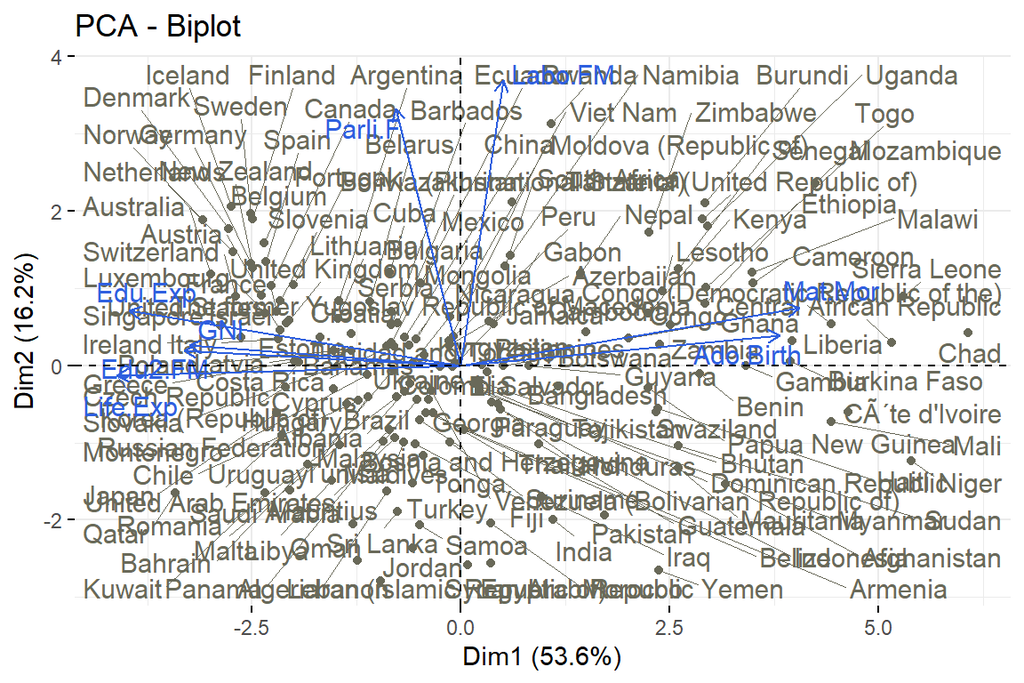

```r
# Anothe way to draw a biplot of the principal component
# Gives percentage variance of PC1 on the x axis and PC2 on the y axis
fviz_pca_biplot(pca_human2, repel = TRUE, col.var = "#2E5FDF", # Variables color
                col.ind = "#696959"  # Individuals color
                )
```

# **Multiple Correspondence Analysis**

```r
# Import data
# Loading FactoMineR
library(FactoMineR)
```

```r
library (ggplot2)
library(dplyr)
library(tidyr)

#Load Tea data
data(tea)

# the structure and
str(tea)
```

```
## 'data.frame':    300 obs. of  36 variables:
##  $ breakfast       : Factor w/ 2 levels "breakfast","Not.breakfast": 1 1 2 2 1 2 1 2 1 1 ...
##  $ tea.time        : Factor w/ 2 levels "Not.tea time",..: 1 1 2 1 1 1 2 2 2 1 ...
##  $ evening         : Factor w/ 2 levels "evening","Not.evening": 2 2 1 2 1 2 2 1 2 1 ...
##  $ lunch           : Factor w/ 2 levels "lunch","Not.lunch": 2 2 2 2 2 2 2 2 2 2 ...
##  $ dinner          : Factor w/ 2 levels "dinner","Not.dinner": 2 2 1 1 2 1 2 2 2 2 ...
##  $ always          : Factor w/ 2 levels "always","Not.always": 2 2 2 2 1 2 2 2 2 2 ...
##  $ home            : Factor w/ 2 levels "home","Not.home": 1 1 1 1 1 1 1 1 1 1 ...
##  $ work            : Factor w/ 2 levels "Not.work","work": 1 1 2 1 1 1 1 1 1 1 ...
##  $ tearoom         : Factor w/ 2 levels "Not.tearoom",..: 1 1 1 1 1 1 1 1 1 2 ...
##  $ friends         : Factor w/ 2 levels "friends","Not.friends": 2 2 1 2 2 2 1 2 2 2 ...
##  $ resto           : Factor w/ 2 levels "Not.resto","resto": 1 1 2 1 1 1 1 1 1 1 ...
##  $ pub             : Factor w/ 2 levels "Not.pub","pub": 1 1 1 1 1 1 1 1 1 1 ...
##  $ Tea             : Factor w/ 3 levels "black","Earl Grey",..: 1 1 2 2 2 2 2 1 2 1 ...
##  $ How             : Factor w/ 4 levels "alone","lemon",..: 1 3 1 1 1 1 1 3 3 1 ...
```

[output cut: 22 more lines]

```r
#the dimensions
dim(tea)
```

```
## [1] 300  36
```

The data is contain the answers of a questionnaire on tea consumption 300 individuals.

We consider the following columns to answer the following:

The kind of tea taken How the tea is taken (alone, w/milk, w/lemon, other) Form of tea used either tea bags, loose tea or both If sugar is used or not Where the tea is bought either the supermarket, shops, both)

```r
# select columns of interest
new_tea = tea[, c("Tea", "How", "how", "sugar", "where")]
# take a look
head(new_tea)
```

```
##         Tea   How     how    sugar       where
## 1     black alone tea bag    sugar chain store
## 2     black  milk tea bag No.sugar chain store
## 3 Earl Grey alone tea bag No.sugar chain store
## 4 Earl Grey alone tea bag    sugar chain store
## 5 Earl Grey alone tea bag No.sugar chain store
## 6 Earl Grey alone tea bag No.sugar chain store
```

Perform MCA

```r
# apply MCA
mca = MCA(new_tea, graph = FALSE)
```

Visualization and interpretation

```r
# table of eigenvalues
mca$eig
```

```
##        eigenvalue percentage of variance cumulative percentage of variance
## dim 1  0.33524490              16.762245                          16.76225
## dim 2  0.30882623              15.441311                          32.20356
## dim 3  0.25731837              12.865918                          45.06947
## dim 4  0.22361328              11.180664                          56.25014
## dim 5  0.19847072               9.923536                          66.17367
## dim 6  0.18376817               9.188408                          75.36208
## dim 7  0.17249065               8.624533                          83.98662
## dim 8  0.14061618               7.030809                          91.01742
## dim 9  0.10497110               5.248555                          96.26598
## dim 10 0.07468041               3.734020                         100.00000
```

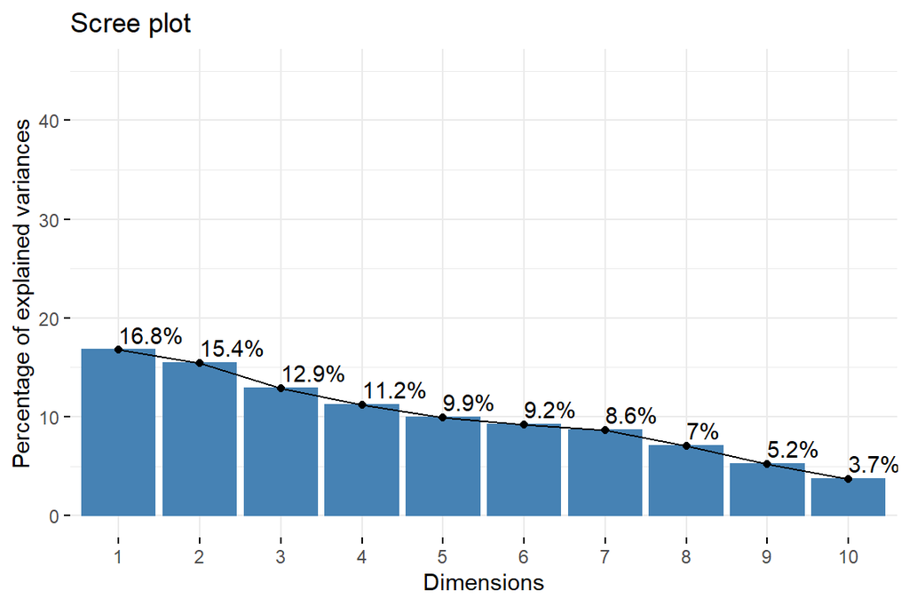

```r
# Plot the eigenvalues
fviz_screeplot(mca, addlabels = TRUE, ylim = c(0, 45))
```

```r
# column coordinates
head(mca$var$coord)
```

```
##                 Dim 1       Dim 2       Dim 3      Dim 4       Dim 5
## black      0.47312391  0.19818117  1.04520460  0.8545399 -0.05679483
## Earl Grey -0.26470789  0.08752788 -0.46234972 -0.1085081 -0.17380989
## green      0.48719553 -0.95631175  0.36025321 -1.2816332  1.14388262
## alone     -0.01717551 -0.25058466  0.14995925 -0.4537372 -0.37775314
## lemon      0.66773816  0.45841522 -1.56133820  0.6258549 -0.36140930
## milk      -0.33762633  0.22018465  0.09285414  0.7795371  1.64433688
```

```r
# row coordinates
head(mca$ind$coord)
```

```
##        Dim 1       Dim 2      Dim 3        Dim 4      Dim 5
## 1 -0.3247111 -0.28824408  0.3046764  0.410521793 -0.2583797
## 2 -0.2589356 -0.07366063  0.7886356  0.691935987  0.6427508
## 3 -0.4031078 -0.28291032  0.2167659 -0.236981750 -0.3175646
## 4 -0.5795738 -0.32806738 -0.2897083  0.003208004 -0.3109117
## 5 -0.4031078 -0.28291032  0.2167659 -0.236981750 -0.3175646
## 6 -0.4031078 -0.28291032  0.2167659 -0.236981750 -0.3175646
```

The results displays the coordinates of each variable categories in each dimension

To visualize the correlation between variables and MCA principal dimensions

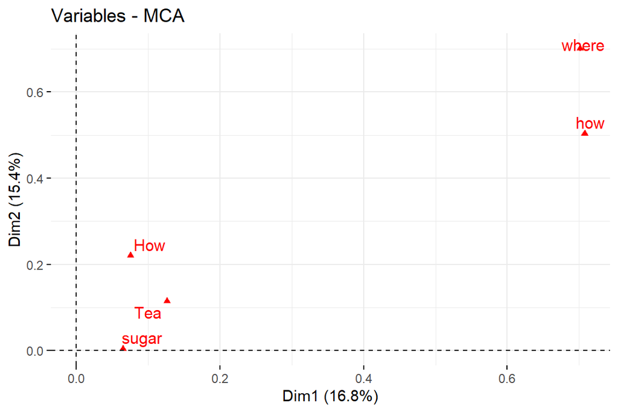

```r
# row coordinates
fviz_mca_var(mca, choice = "mca.cor",
            repel = TRUE, # Avoid text overlapping (slow)
            ggtheme = theme_minimal())
```

The plot above helps to assess the variables that are the most correlated with each of the dimension. The squared correlations between variables and the dimensions are used as coordinates.

It can be seen that, the variables “where” and “how” are both correlated to both dimension 1 and 2. “How” is more correlated with dimension 2.

Note How- how the tea is taken (alone, w/milk, w/lemon, other) how- Form of tea used either tea bags, loose tea or both If sugar is used or not Where- where the tea is bought either the supermarket, shops, both)

Additional plots

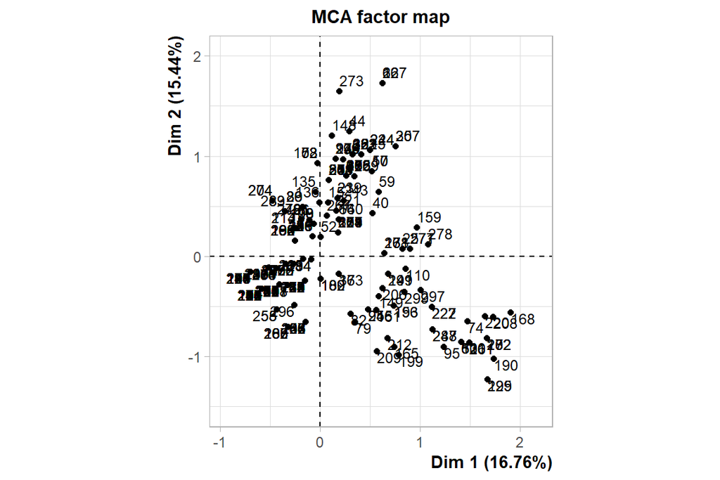

```r
plot.MCA(mca, invisible=c("var","quali.sup"), cex=0.8)
```

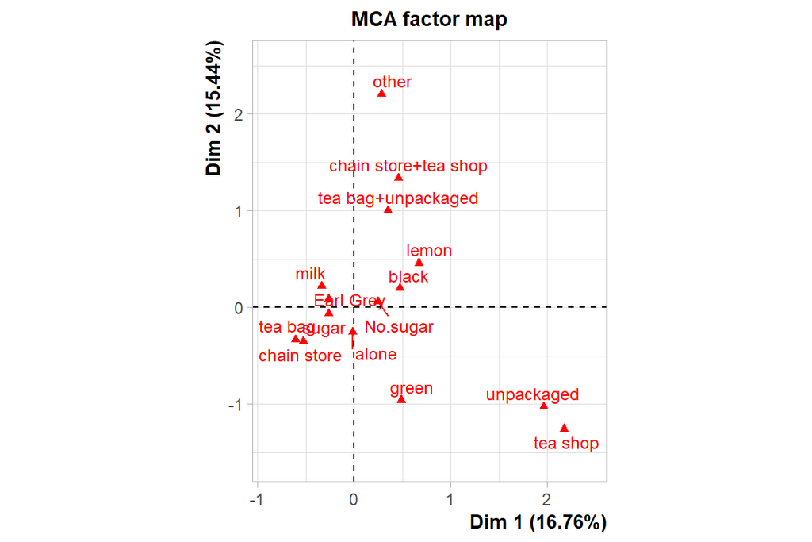

```r
plot.MCA(mca, invisible=c("ind","quali.sup"), cex=0.8)
```